# intro normal

Ahmet KURNAZ

2023-06-21

## Data Types and Structures

- Data is everywhere?
- How big is data?

## Categorical

- Categorical data: These are data types that can be divided into several categories but having no order or priority.
- Example: Religious affiliations (e.g., Christian, Muslim, Jewish, etc.), types of government (e.g., democracy, autocracy), gender (male, female, others).

```r
# define a categorical variable
gender <- factor(c("male", "female", "male", "female", "male"))

# print the variable
print(gender)
```

```
## [1] male   female male   female male
## Levels: female male
```

## Ordinal

- Ordinal data: This is a type of categorical data with a set order or scale.
- Example: Rating scales (e.g., on a scale of 1-5 how happy are you with the government’s performance?), education level (high school, bachelor’s, master’s, doctorate), socio-economic status (low, middle, high).

```r
# define an ordered variable
education_level <- factor(c("high school", "bachelor's", "master's", "doctorate"),
                          ordered = TRUE,
                          levels = c("high school", "bachelor's", "master's", "doctorate"))

# print the variable
print(education_level)
```

```
## [1] high school bachelor's  master's    doctorate
## Levels: high school < bachelor's < master's < doctorate
```

## Numeric

- Numerical/Quantitative data: This is data expressed in numbers, further split into two categories: discrete and continuous.
- Discrete data: These are countable values (integers).
- Example: Number of children in a family, number of students in a school, number of people who vote in an election.
- Continuous data: These are measurable quantities (real numbers).
- Example: GDP, income, age, or weight of a person.

```r
# define a numerical variable
age <- c(23, 24, 22, 25, 23)

# print the variable
print(age)
```

```
## [1] 23 24 22 25 23
```

## Binary

- Binary data: A subtype of categorical data where the variable has only two categories.
- Example: Yes/No responses, presence/absence.

```r
# define a binary variable
is_married <- factor(c("yes", "no", "yes", "yes", "no"))

# print the variable
print(is_married)
```

```
## [1] yes no  yes yes no
## Levels: no yes
```

## Time

- Time-series data: This is data collected over time.
- Example: Unemployment rates from 2000 to 2020, daily temperature readings, stock prices over time.

```r
# define a time series
sales <- ts(c(123, 129, 131, 120, 135, 150), start = c(2022, 1), frequency = 12)

# print the time series
print(sales)
```

```
##      Jan Feb Mar Apr May Jun
## 2022 123 129 131 120 135 150
```

## Location/Geometry

- Spatial data: This data has a geographical or spatial aspect.
- Example: Population density in different regions, disease spread across different areas.

```r
# you will need to install the sp package
# install.packages("sp")

library(sp)
# create a SpatialPoints object
coords <- matrix(c(2, 3, 5, 6), ncol = 2)
sp_points <- SpatialPoints(coords)

# print the SpatialPoints object
print(sp_points)
```

```
## SpatialPoints:
##      coords.x1 coords.x2
## [1,]         2         5
## [2,]         3         6
## Coordinate Reference System (CRS) arguments: NA
```

## Text

- Text data: Large collections of documents, such as survey responses or social media posts, are often treated as a ‘bag of words’ or more sophisticated structures like trees (for sentence structure) or graphs (for document similarities).

```r
# you will need to install the tm package
# install.packages("tm")

library(tm)
# create a text document
text <- "This is an example of text data."
doc <- Corpus(VectorSource(text))

# print the document
print(doc)
```

```
## <<SimpleCorpus>>
## Metadata:  corpus specific: 1, document level (indexed): 0
## Content:  documents: 1
```

## Audio

- Audio Data: Audio data can be converted into a format suitable for data analysis through a process known as feature extraction.
- Example: Analyzing speech patterns and voice intonations in interviews or focus groups. Studying acoustic environment of a location for urban planning or environmental studies. Analyzing the use of language in public speeches or radio shows.

```r
# you will need to install the tuneR package
# install.packages("tuneR")

library(tuneR)
# read a .wav file
# sound <- readWave("path/to/your/audio.wav")
#
# print the Wave object
# print(sound)
```

## Image

- Image Data: Images can offer a wealth of information, especially with the rise of machine learning techniques for image analysis.
- Example: Analyzing satellite images to study urban sprawl or deforestation. Studying social media profile pictures for trends and correlations with other data like age, profession or location. Facial analysis for understanding human emotions in reaction to certain social events.

```r
# you will need to install the imager package
# install.packages("imager")

library(imager)
# load an image
# img <- load.image("path/to/your/image.jpg")

# display the image
# plot(img)
```

## Video

- Video Data: Like images, videos can be a rich source of data. They can provide insights into human behavior and social interactions.
- Example: Observing crowd behavior during public events, studying body language in political debates, analyzing traffic patterns in cities, or understanding consumer behavior in retail environments.

```r
# you will need to install the video package
# install.packages("video")

library(video)
# read a video file
# vid <- video::readVideo("path/to/your/video.mp4")

# print the video data
# print(vid)
```

## Data Frames

- Data Frames: Data is often organized into rows and columns, like in an Excel spreadsheet or a CSV file.
- Example: A table listing the GDP of every country for each year.

```r
# define a data frame
df <- data.frame(
    "Name" = c("John", "Sarah", "Mike"),
    "Age" = c(23, 25, 22),
    "Salary" = c(55000, 65000, 70000)
)

# print the data frame
print(df)
```

```
##    Name Age Salary
## 1  John  23  55000
## 2 Sarah  25  65000
## 3  Mike  22  70000
```

## Lists

- Lists: A list is a collection of items. It can be a simple list (like a list of names) or a more complex list where each item is a table or another list.
- Example: A list of tables where each table represents data from a different source.

```r
# define a list
list <- list("Name" = "John", "Age" = 23, "Salary" = 55000)

# print the list
print(list)
```

```
## $Name
## [1] "John"
##
## $Age
## [1] 23
##
## $Salary
## [1] 55000
```

## Arrays/Matrices

- Arrays/Matrices: These are used when working with numerical data. They can be 1-D (like a list), 2-D (like a data frame), or higher-dimensional.
- Example: A 2-D array where each row represents a person and each column represents a different attribute of that person (age, income, etc.).

```r
# define a matrix
mat <- matrix(c(1, 2, 3, 4, 5, 6), nrow = 2, ncol = 3)

# print the matrix
print(mat)
```

```
##      [,1] [,2] [,3]
## [1,]    1    3    5
## [2,]    2    4    6
```

## Graphs

- Graphs: These are used to model relationships between entities.
- Example: A graph where each node represents a person and each edge represents a social relationship between two people.

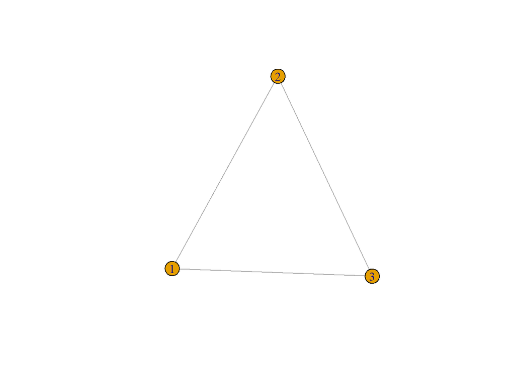

```r
# you will need to install the igraph package
# install.packages("igraph")

library(igraph)
# create a graph
g <- graph(edges=c(1,2, 2,3, 3,1), n=3, directed=F)

# plot the graph
plot(g)
```

## Dictionaries/Maps

- Dictionaries/Maps: These contain key-value pairs where each key is linked to a value.
- Example: A map where each key is a country name and each value is the population of that country.

```r
# define a list as a map
map <- list("USA" = "Washington D.C.", "UK" = "London", "France" = "Paris")

# print the map
print(map)
```

```
## $USA
## [1] "Washington D.C."
##
## $UK
## [1] "London"
##
## $France
## [1] "Paris"
```